# main_notebook

```r
data <- read_csv("C:/Users/User/Downloads/data_analitycs/Diabetes-study/lab1-EDA/data/diabetic_data.csv")
str(data, give.attr = FALSE)
```

```
spc_tbl_ [101,766 × 50] (S3: spec_tbl_df/tbl_df/tbl/data.frame)
 $ encounter_id            : num [1:101766] 2278392 149190 64410 500364 16680 ...
 $ patient_nbr             : num [1:101766] 8222157 55629189 86047875 82442376 42519267 ...
 $ race                    : chr [1:101766] "Caucasian" "Caucasian" "AfricanAmerican" "Caucasian" ...
 $ gender                  : chr [1:101766] "Female" "Female" "Female" "Male" ...
 $ age                     : chr [1:101766] "[0-10)" "[10-20)" "[20-30)" "[30-40)" ...
 $ weight                  : chr [1:101766] "?" "?" "?" "?" ...
 $ admission_type_id       : num [1:101766] 6 1 1 1 1 2 3 1 2 3 ...
 $ discharge_disposition_id: num [1:101766] 25 1 1 1 1 1 1 1 1 3 ...
 $ admission_source_id     : num [1:101766] 1 7 7 7 7 2 2 7 4 4 ...
 $ time_in_hospital        : num [1:101766] 1 3 2 2 1 3 4 5 13 12 ...
 $ payer_code              : chr [1:101766] "?" "?" "?" "?" ...
 $ medical_specialty       : chr [1:101766] "Pediatrics-Endocrinology" "?" "?" "?" ...
 $ num_lab_procedures      : num [1:101766] 41 59 11 44 51 31 70 73 68 33 ...
 $ num_procedures          : num [1:101766] 0 0 5 1 0 6 1 0 2 3 ...
```

[output cut: 36 more lines]

```r
table(data$number_inpatient)
```

```
    0     1     2     3     4     5     6     7     8     9    10    11    12    13    14    15    16    17
67630 19521  7566  3411  1622   812   480   268   151   111    61    49    34    20    10     9     6     1
   18    19    21
    1     2     1
```

кількість спост. кожної раси

```r
table(data$race)
```

[output not shown]

кількість спост. кожного гендеру

```r
table(data$gender)
```

```
         Female            Male Unknown/Invalid
          54708           47055               3
```

кількість спост. кожної вікової групи

```r
table(data$age)
```

```
  [0-10)  [10-20)  [20-30)  [30-40)  [40-50)  [50-60)  [60-70)  [70-80)  [80-90) [90-100)
     161      691     1657     3775     9685    17256    22483    26068    17197     2793
```

Після перетворення змінних у фактори:

```r
str(data)
```

підраховуємо кількість пропущених значень в кожному стовпчику

```r
data %>%
  summarize(across(everything(), ~ sum(is.na(.)))) %>%
  select(where(~ all(.) > 0))
```

частка пропущених значень в кожному стовпчику //(після всіх об’єднань в NA слід перерахувати та надати Таврову як результат дескриптивного аналізу (аля обробка даних))//

```r
data %>%
  summarize(across(everything(), ~ mean(is.na(.)) * 100)) %>%  # Обчислення відсотка NA
  select(where(~ . > 0))  # Вибір колонок, де відсоток NA більше 0
```

графік середня кількість госпіталізацій за статтю

```r
data_gender_clean <- data %>%
  filter(!(gender %in% c("Unknown/Invalid", "Uknown/Invalid")))

data_summary_gender <- data_gender_clean %>%
  group_by(gender) %>%
  summarise(
    avg_hosp = mean(number_inpatient, na.rm = TRUE),
    count = n()
  )

ggplot(data_summary_gender, aes(x = gender, y = avg_hosp, fill = gender)) +
  geom_col(alpha = 0.8) +
  scale_x_discrete(labels = c("Female" = "жіноча", "Male" = "чоловіча")) +
  labs(title = "Середня кількість госпіталізацій за статтю",
       x = "Стать",
       y = "Середня кількість госпіталізацій") +
  theme_minimal() +
  theme(legend.position = "none")
```

графік відсоток спостережень за статтю

```r
data_prop_gender <- data_gender_clean %>%
  count(gender) %>%
  mutate(percentage = n / sum(n) * 100)

ggplot(data_prop_gender, aes(x = gender, y = percentage, fill = gender)) +
  geom_col(alpha = 0.8) +
  scale_x_discrete(labels = c("Female" = "жіноча", "Male" = "чоловіча")) +
  labs(title = "Відсоток спостережень за статтю",
       x = "Стать",
       y = "Відсоток (%)") +
  theme_minimal()+
  theme(legend.position = "none")
```

QQPlot для кількості госпіталізацій за статтю

```r
ggplot(data_gender_clean, aes(sample = number_inpatient)) +
  stat_qq() +
  stat_qq_line() +
  facet_wrap(~ gender) +
  labs(title = "QQPlot для кількості госпіталізацій за статтю",
       x = "Квантилі теоретичного розподілу",
       y = "Квантилі вибірки") +
  theme_minimal()
```

кількість пацієнтів чоловічої та жіночої статі у всьому датасеті

```r
data_clean <- data %>%
  filter(!(gender %in% c("Unknown/Invalid", "Uknown/Invalid")))

data_clean %>%
  count(gender)
```

діаграма порівняння часток пацієнтів за статтю залежно від кількості госпіталізацій

```r
data_gender_clean %>%
  group_by(gender, number_inpatient) %>%
  summarise(count = n()) %>%
  group_by(gender) %>%
  mutate(prop = count / sum(count)) %>%
  ggplot(aes(x = factor(number_inpatient), y = prop, fill = gender)) +
  geom_bar(stat = "identity", position = "dodge") +
  scale_fill_discrete(name = "Стать пацієнта",
                      labels = c("Female" = "Жіноча", "Male" = "Чоловіча")) +
  labs(title = "Порівняння часток за статтю",
       x = "Кількість госпіталізацій", y = "Пропорція")
```

діаграма роподілу кількості госпіталізацій

```r
data_gender_clean %>%
  group_by(number_inpatient, gender) %>%
  summarise(count = n()) %>%
  ggplot(aes(x = factor(number_inpatient), y = count, fill = gender)) +
  geom_bar(stat = "identity") +
  scale_fill_discrete(name = "Стать пацієнта",
                      labels = c("Female" = "Жіноча", "Male" = "Чоловіча")) +
  labs(title = "Розподіл кількості госпіталізацій",
       x = "Кількість госпіталізацій", y = "Кількість пацієнтів")
```

підрахунок коеєфіцєнту точково бісеріальної кореляції між гендером та кількістю госпіталізацій

```r
library(psych)

correlation <- biserial(data_gender_clean$number_inpatient,
                        ifelse(data_gender_clean$gender == "Female", 1, 0))

print(correlation)
```

Чи впливає кількість встановлених діагнозів на тривалість госпіталізації?

box plots відповідних змінних

```r
ggplot(data = data, aes(y = time_in_hospital)) +
  geom_boxplot(fill = "skyblue", color = "black", outlier.colour = "red") +
  labs(
    title = "Розподіл годин, проведених пацієнтами у лікарні",
    y = "Години у лікарні"
  ) +
  theme_minimal()
```

```r
ggplot(data = data, aes(y = number_diagnoses)) +
  geom_boxplot(fill = "skyblue", color = "black", outlier.colour = "red") +
  labs(
    title = "Розподіл кількості встановлених діагнозів",
    y = "Кількість діагнозів"
  ) +
  theme_minimal()
```

```r
ggplot(data_gender_clean, aes(x = number_diagnoses, y = time_in_hospital)) +
  geom_point(aes(color = gender), alpha = 0.6) +
  facet_wrap(~ gender, labeller = as_labeller(c("Female" = "Жінки", "Male" = "Чоловіки"))) +
  labs(title = "Тренд по категоріям (гендеру)",
       x = "Кількість діагнозів",
       y = "Час в лікарні") +
  scale_color_discrete(name = "Стать пацієнта",
                       labels = c("Female" = "Жіноча", "Male" = "Чоловіча")) +
  theme_minimal()
```

кореляція спірмена

```r
cor.test(data$number_diagnoses, data$time_in_hospital, method = "spearman", exact = FALSE)
```

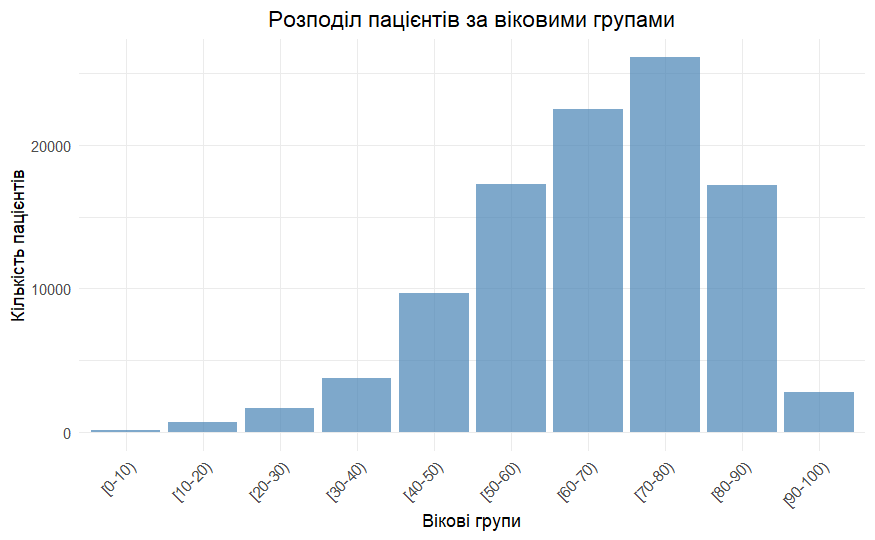

```r
ggplot(data, aes(x = age)) +
  geom_bar(fill = "steelblue", alpha = 0.7) +
  labs(title = "Розподіл пацієнтів за віковими групами",
       x = "Вікові групи",
       y = "Кількість пацієнтів") +
  theme_minimal() +
  theme(
    plot.title = element_text(hjust = 0.5),  # Центрування заголовка
    axis.text.x = element_text(angle = 45, hjust = 1)  # Нахил підписів на осі X
  )
```

Висновок:

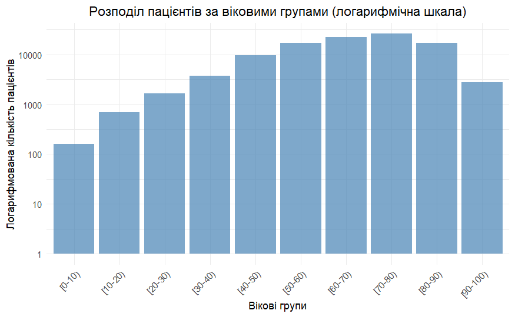

```r
ggplot(data, aes(x = age)) +
  geom_bar(fill = "steelblue", alpha = 0.7) +
  scale_y_log10() +  # Логарифмування осі Y
  labs(title = "Розподіл пацієнтів за віковими групами (логарифмічна шкала)",
       x = "Вікові групи",
       y = "Логарифмована кількість пацієнтів") +
  theme_minimal() +
  theme(
    plot.title = element_text(hjust = 0.5),  # Центрування заголовка
    axis.text.x = element_text(angle = 45, hjust = 1)  # Нахил підписів на осі X
  )
```

```r
NA
NA
```

//Висновки по розподілу вікових груп. Бачимо, що основна група ризику це особи віком від 50 до 90 (+значне зростання випадків у групі 30-40 (можна далі розвивати питання віку для початку профілактики захворювання діабетом)), бачимо також різке спадання на групі 90-100, але це пов’язано скоріше з тривалістю життя людей. (загалом мала частка людей 90+, а за відбором по специфічному параметру ше менше). В молодому віці (від 0 до 30) загалом мала кількість випадків захворювання **Не впевнений в необхідності показувати логарифмічний графік (на загальний розсуд)** Логарифмічний графік дозволяє краще візуалізувати різницю між групами з невеликою кількістю пацієнтів. На ньому видно, що хоча в молодших вікових групах пацієнтів значно менше, тенденція зростання є поступовою.//

//Дослідження статистично значущих відмінностей у расових групах щодо тривалості госпіталізації (Na + other об’єднав)

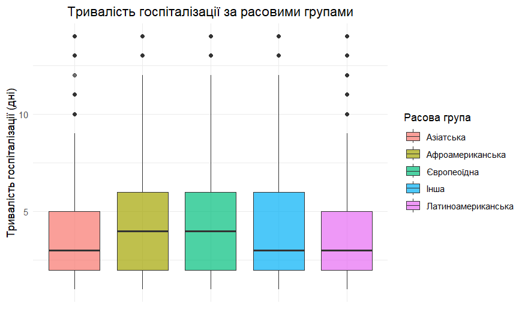

```r
# Побудова графіка
ggplot(data, aes(x = race, y = time_in_hospital, fill = race)) +
  geom_boxplot(alpha = 0.7) +
  labs(title = "Тривалість госпіталізації за расовими групами",
       x = "",
       y = "Тривалість госпіталізації (дні)",
       fill = "Расова група") +  # Оновлена назва легенди
  theme_minimal() +
  theme(
    plot.title = element_text(hjust = 0.5),# Центрування заголовка
    axis.text.x = element_blank(),
    axis.ticks.x = element_blank(),
    legend.position = "right"  # Якщо потрібно відобразити легенду
  )
```

```r
NA
NA
```

```r
cor.test(data$number_diagnoses[data$gender == "Male"],
         data$time_in_hospital[data$gender == "Male"],
         method = "spearman", exact = FALSE)
```

```
    Spearman's rank correlation rho

data:  data$number_diagnoses[data$gender == "Male"] and data$time_in_hospital[data$gender == "Male"]
S = 1.329e+13, p-value < 2.2e-16
alternative hypothesis: true rho is not equal to 0
sample estimates:
      rho
0.2346507
```

```r
cor.test(data$number_diagnoses[data$gender == "Female"],
         data$time_in_hospital[data$gender == "Female"],
         method = "spearman", exact = FALSE)
```

```
    Spearman's rank correlation rho

data:  data$number_diagnoses[data$gender == "Female"] and data$time_in_hospital[data$gender == "Female"]
S = 2.078e+13, p-value < 2.2e-16
alternative hypothesis: true rho is not equal to 0
sample estimates:
      rho
0.2385489
```

Чи є відмінності в рівні смертності між різними віковими групами?

```r
data$status <- ifelse(data$discharge_disposition_id %in% c(11, 19, 20, 21), "Помер", "Вижив")

# Побудова складеної стовпчастої діаграми
ggplot(data, aes(x = age, fill = status)) +
    geom_bar() +
    labs(
        title = "Рівень смертності у різних вікових групах",
        x = "Вікові групи",
        y = "Кількість пацієнтів",
        fill = NULL
    ) +
    scale_fill_manual(values = c("Помер" = "red", "Вижив" = "green")) +
    theme_minimal()
```

[output not shown]

```r
age_mapping <- c('[0-10)' = 5, '[10-20)' = 15, '[20-30)' = 25,
                  '[30-40)' = 35, '[40-50)' = 45, '[50-60)' = 55,
                  '[60-70)' = 65, '[70-80)' = 75, '[80-90)' = 85,
                  '[90-100)' = 95)
data$age_bin <- as.numeric(recode(data$age, !!!age_mapping))

# Построение Violin Plot
ggplot(data, aes(x = data$status, y = age_bin, fill = data$status)) +
  geom_violin(trim = FALSE) +
  geom_boxplot(width = 0.1, color = "black", alpha = 0.3) +
  labs(
    title = "Смертність пацієнтів по віковим категоріям",
    x = "Статус",
    y = "Вік",
    fill = NULL
  ) +
  scale_fill_manual(values = c("Помер" = "red", "Вижив" = "green"))+
  theme_minimal()
```

[output not shown]

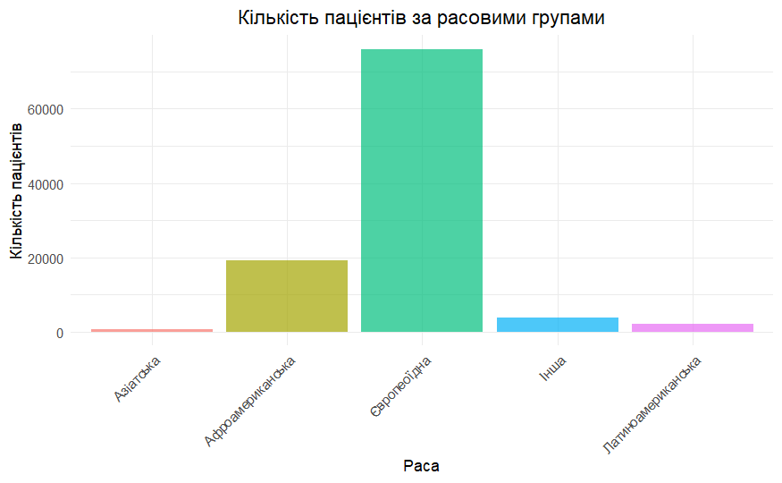

```r
ggplot(data, aes(x = race, fill = race)) +
  geom_bar(alpha = 0.7) +

  labs(title = "Кількість пацієнтів за расовими групами",
       x = "Раса",
       y = "Кількість пацієнтів") +
  theme_minimal() +
  theme(
    plot.title = element_text(hjust = 0.5),
    axis.text.x = element_text(angle = 45, hjust = 1), legend.position = "none")
```

```r
# Підрахуємо кількість людей за кожною расою та обчислимо відносну частку
race_counts <- data %>%
  group_by(race) %>%
  summarise(count = n()) %>%
  mutate(relative_percentage = count / sum(count) * 100)

# Виведемо результат
print(race_counts)
```

| race | count | relative_percentage |
| --- | --- | --- |
| ? | 2273 | 2.2335554 |
| AfricanAmerican | 19210 | 18.8766386 |
| Asian | 641 | 0.6298764 |
| Caucasian | 76099 | 74.7784132 |
| Hispanic | 2037 | 2.0016508 |
| Other | 1506 | 1.4798656 |

```r
NA
```

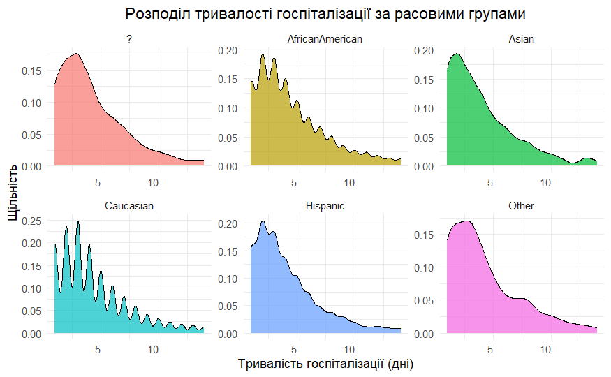

```r
ggplot(data, aes(x = time_in_hospital, fill = race)) +
  geom_density(alpha = 0.7) +
  facet_wrap(~ race, scales = "free") +
  labs(title = "Розподіл тривалості госпіталізації за расовими групами",
       x = "Тривалість госпіталізації (дні)",
       y = "Щільність") +
  theme_minimal() +
  theme(plot.title = element_text(hjust = 0.5),
    axis.text.x = element_text(angle = 0, hjust = 1), legend.position = "none")
```

```r
# Крос-таблиця типу виписки та повторної госпіталізації
table(data$discharge_disposition_id, data$readmitted)
```

```
       <30   >30    NO
  1   5602 21517 33115
  2    342   668  1118
  3   2046  4916  6992
  4    104   278   433
  5    247   350   587
  6   1638  5362  5902
  7     90   221   312
  8     15    38    55
  9      9     2    10
  10     0     4     2
  11     0     0  1642
  12     2     0     1
  13    19    36   344
  14    24     7   341
  15    28    18    17
  16     0     6     5
  17     0     5     9
  18   459  1027  2205
  19     0     0     8
  20     0     0     2
  22   552   519   922
  23    30   144   238
  24     7    16    25
  25    92   376   521
  27     0     1     4
  28    51    34    54
```

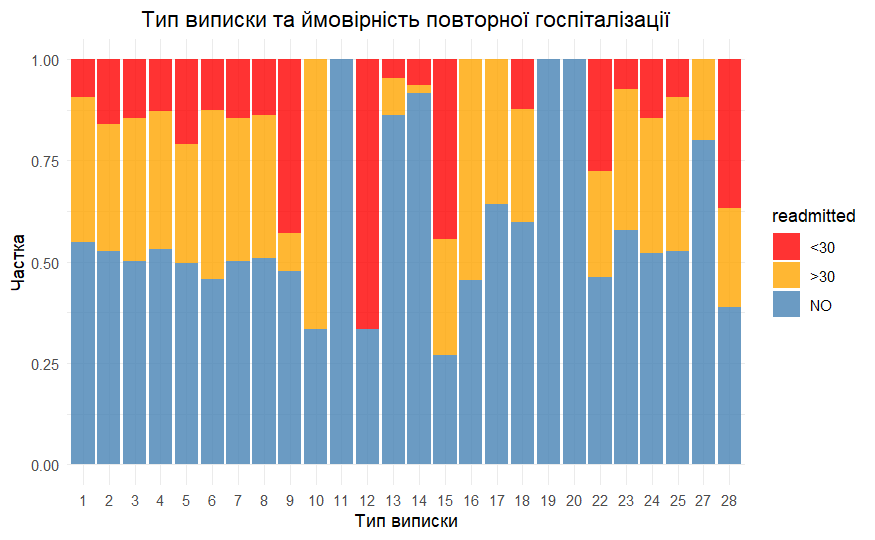

```r
ggplot(data, aes(x = as.factor(discharge_disposition_id), fill = readmitted)) +
  geom_bar(position = "fill", alpha = 0.8) +
  labs(title = "Тип виписки та ймовірність повторної госпіталізації",
       x = "Тип виписки",
       y = "Частка") +
  theme_minimal() +
  scale_fill_manual(values = c("NO" = "steelblue", "<30" = "red", ">30" = "orange"))+
  theme(plot.title = element_text(hjust = 0.5))
```

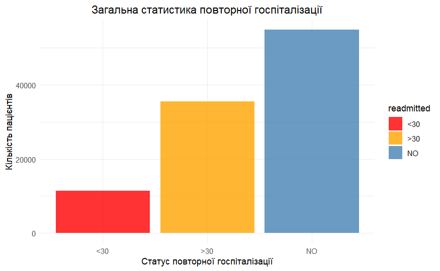

```r
# Підрахунок кількості пацієнтів у кожній категорії readmitted
summary_stats <- data %>%
  group_by(readmitted) %>%
  summarise(Кількість = n())

# Побудова графіка
ggplot(summary_stats, aes(x = readmitted, y = Кількість, fill = readmitted)) +
  geom_bar(stat = "identity", alpha = 0.8) +
  labs(title = "Загальна статистика повторної госпіталізації",
       x = "Статус повторної госпіталізації",
       y = "Кількість пацієнтів") +
  theme_minimal() +
  scale_fill_manual(values = c("NO" = "steelblue", "<30" = "red", ">30" = "orange")) +
  theme(plot.title = element_text(hjust = 0.5))
```

discharge_disposition_id українською:

1 - Виписаний додому 2 - Виписаний/переведений до іншої короткострокової лікарні 3 - Виписаний/переведений до будинку для літніх людей (SNF) 4 - Виписаний/переведений до закладу інтенсивного догляду (ICF) 5 - Виписаний/переведений до іншого стаціонарного закладу 6 - Виписаний/переведений додому з послугами домашнього догляду 7 - Виписаний за власним бажанням (Left AMA) 8 - Виписаний/переведений додому під наглядом провайдера Home IV 9 - Госпіталізований як стаціонарний пацієнт у цю лікарню 10 - Немовля, виписане до іншої лікарні для неонатального догляду 11 - Помер 12 - Все ще є пацієнтом або очікує повернення для амбулаторних послуг 13 - Хоспіс / догляд вдома 14 - Хоспіс / медичний заклад 15 - Виписаний/переведений у межах цього закладу до ліжка з медичним страхуванням Medicare 16 - Виписаний/переведений/направлений до іншого закладу для амбулаторних послуг 17 - Виписаний/переведений/направлений до цього закладу для амбулаторних послуг 18 - Немає даних (NULL) 19 - Помер удома (тільки Medicaid, хоспіс) 20 - Помер у медичному закладі (тільки Medicaid, хоспіс) 21 - Помер, місце невідоме (тільки Medicaid, хоспіс) 22 - Виписаний/переведений до іншого реабілітаційного закладу, включаючи реабілітаційні відділення лікарень 23 - Виписаний/переведений до лікарні тривалого догляду 24 - Виписаний/переведений до медсестринського закладу, сертифікованого за Medicaid, але не сертифікованого за Medicare 25 - Не віднесено до категорії 26 - Невідомо / недійсно 27 - Виписаний/переведений до федерального медичного закладу 28 - Виписаний/переведений/направлений до психіатричної лікарні або психіатричного відділення лікарні

Виписки 11,19,20 - різні типи смерті, не несуть статистичного сенсу Лікування діабету це постійний процес, що потребує медичних втручань, тому сфокусуємося саме на повторних госпіталізаціях в короткий час Виписки 1-8 загалом мають схожу статистику, близько половини не повертаються та ще ~третини >30, немає відмінностей від загальної статистики. Виділимо відмінні від загальної статистики типи та прокоментуємо Виписки 9 12 15 цікаві великою к-стю повторних госпіталізацій менш як за 30 днів. Виписки 13 14 - переведення до госпіс, майже всі не госпіталізуються повторно Виписка 27 не має повторних госпіталізацій <30 днів та незначну к-сть >30, близько 80% не госпіталізуються повторно Виписки 16 17 лише >30 або NO (для 16 55/45 для 17 40/60) Виписка 28 має значну к-сть <30

Загальний висновок:

1. Існує певний взаємозв’язок між типом виписки та ймовірністю повторної госпіталізації. Різні типи виписки мають суттєво різний розподіл повторних госпіталізацій. Деякі категорії пацієнтів повертаються частіше, особливо в межах 30 днів, тоді як інші майже ніколи не повертаються.
2. Виписки з високою ймовірністю швидкої повторної госпіталізації (<30 днів): Госпіталізовані знову в ту ж лікарню (9)

Все ще є пацієнтами або очікують амбулаторних послуг (12)

Переведені в межах закладу (15)

Переведені до психіатричної лікарні (28)

Це свідчить про те, що пацієнти з цих категорій мають нестабільний стан або потребують тривалого медичного догляду.

3. Виписки з низькою ймовірністю повторної госпіталізації: Пацієнти, переведені до хоспісу (13, 14)

Федеральні медичні заклади (27) Тут повторні госпіталізації майже відсутні, що логічно, оскільки ці пацієнти отримують спеціалізований догляд, який зменшує потребу у повторних госпіталізаціях.

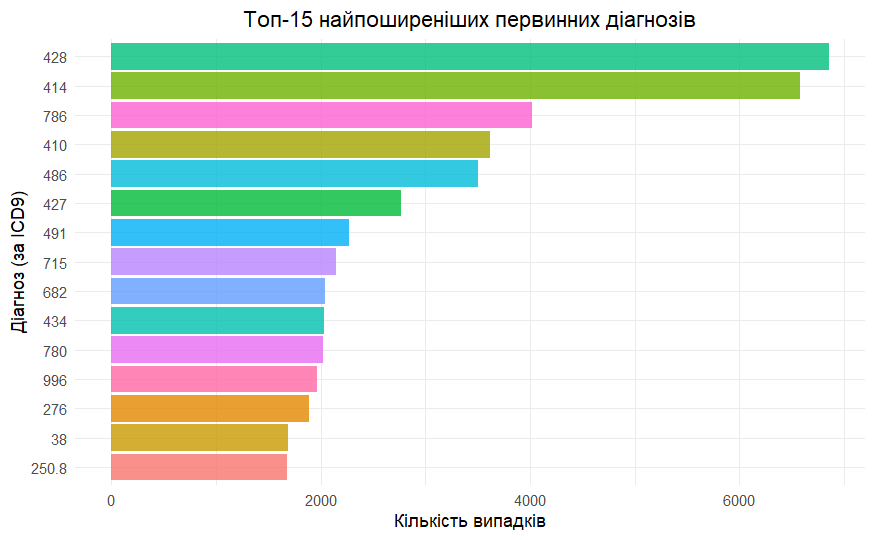

```r
# Топ-10 найпоширеніших діагнозів
top_diagnoses <- data %>%
  count(diag_1) %>%
  arrange(desc(n)) %>%
  top_n(15, n)

ggplot(top_diagnoses, aes(x = reorder(diag_1, n), y = n, fill = diag_1)) +
  geom_col(alpha = 0.8) +
  coord_flip() +
  labs(title = "Топ-15 найпоширеніших первинних діагнозів",
       x = "Діагноз (за ICD9)",
       y = "Кількість випадків") +
  theme_minimal() +
  theme(plot.title = element_text(hjust = 0.5),
        legend.position = "none")
```

Найпоширеніші первинні діагнози. Вони в нас закодовані за ICD9 (пояснення кодів взято з ICD9Data.com) 428 - heart failure (Серцева недостатність) 414 - Coronary atherosclerosis of unspecified type of vessel, native or graft (Коронарний атеросклероз невизначеного типу судини, власної або трансплантованої) 786 - Symptoms involving respiratory system and other chest symptoms (Симптоми, пов’язані з дихальною системою та інші симптоми грудної клітки) 410 - Acute myocardial infarction (Гострий інфаркт міокарда) 486 - Pneumonia, organism unspecified (Пневмонія, невизначений збудник) 427 - Cardiac dysrhythmias (Порушення серцевого ритму) 491 - Chronic bronchitis (Хронічний бронхіт) 715 - Osteoarthrosis and allied disorders (Остеоартроз та споріднені порушення) 682 - Other cellulitis and abscess (Інші види целюліту та абсцесів) 434 - Occlusion of cerebral arteries (Закупорка мозкових артерій) 780 - Alteration of consciousness General symptoms (Порушення свідомості, загальні симптоми) 996 - Complications peculiar to certain specified procedures (Ускладнення, властиві певним специфічним процедурам) 276 - Disorders of fluid electrolyte and acid-base balance (Порушення балансу рідин, електролітів і кислотно-лужного балансу) 38 - Incision, Excision, And Occlusion Of Vessels (Розсічення, висічення та оклюзія судин) 250.8 - Diabetes with other specified manifestations (Цукровий діабет з іншими специфікованими ускладненнями)

!!! Ремарка: ці висновки можна просто зчитати і вивести лише графік під час захисту !!!

цукровий діабет (код 250.8) знаходиться лише на 15-му місці серед найпоширеніших первинних діагнозів у пацієнтів, які мали цей стан. Це означає, що сам по собі діабет рідко фігурує як основний діагноз, а частіше він асоціюється з іншими серйозними захворюваннями, які можуть бути його ускладненнями або мати спільні фактори ризику.

Основні висновки з аналізу топ-15 діагнозів у пацієнтів із діабетом: Серцево-судинні захворювання домінують Heart failure (428) – Серцева недостатність Coronary atherosclerosis (414) – Коронарний атеросклероз Acute myocardial infarction (410) – Гострий інфаркт міокарда Cardiac dysrhythmias (427) – Порушення серцевого ритму Occlusion of cerebral arteries (434) – Закупорка мозкових артерій

→ Це узгоджується з тим, що діабет значно підвищує ризик серцево-судинних подій через гіперглікемію, запалення та атеросклероз.

Проблеми з легенями та інфекції Pneumonia (486) – Пневмонія Chronic bronchitis (491) – Хронічний бронхіт Symptoms involving respiratory system (786) – Дихальні симптоми

→ Діабетики мають ослаблений імунітет, що робить їх більш вразливими до інфекцій, включаючи пневмонію та бронхіт.

Метаболічні та електролітні порушення Disorders of fluid, electrolyte, and acid-base balance (276)

→ Діабет впливає на нирки та водно-електролітний баланс, що може призводити до гіперглікемічного стану, кетоацидозу чи гіпонатріємії.

Ускладнення через процедури та операції

Complications of procedures (996) Incision, excision, and occlusion of vessels (38)

→ Діабетики часто потребують хірургічних втручань через судинні ураження, що пояснює частоту ускладнень після процедур.

Головний висновок: Діабет рідко є первинним діагнозом, але значно підвищує ризик серцевих, судинних, респіраторних та інфекційних ускладнень. Це підтверджує важливість контролю рівня глюкози, артеріального тиску та ліпідів, щоб зменшити ризик важких ускладнень.

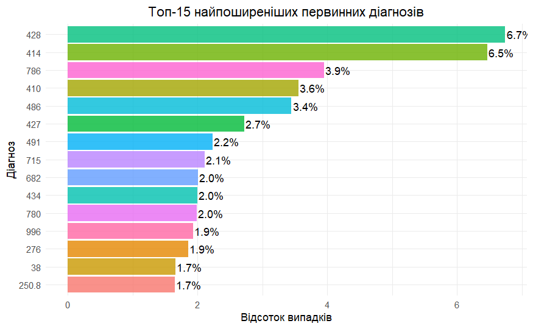

```r
# Загальна кількість записів для розрахунку відсотків
total_cases <- nrow(data)

# Топ-15 найпоширеніших діагнозів з відсотками
top_diagnoses <- data %>%
  count(diag_1) %>%
  arrange(desc(n)) %>%
  top_n(15, n) %>%
  mutate(percentage = (n / total_cases) * 100)  # Додаємо відсотки

# Візуалізація
ggplot(top_diagnoses, aes(x = reorder(diag_1, n), y = percentage, fill = diag_1)) +
  geom_col(alpha = 0.8) +
  coord_flip() +
  labs(title = "Топ-15 найпоширеніших первинних діагнозів",
       x = "Діагноз",
       y = "Відсоток випадків") +
  theme_minimal() +
  theme(plot.title = element_text(hjust = 0.5),
        legend.position = "none") +
  geom_text(aes(label = sprintf("%.1f%%", percentage)), hjust = -0.05)  # Додаємо підписи у %
```

```r
# Середня тривалість госпіталізації за типами
data %>%
  group_by(admission_type_id) %>%
  summarise(avg_days = mean(time_in_hospital, na.rm = TRUE)) %>%
  arrange(desc(avg_days))
```

| admission_type_id | avg_days |
| --- | --- |
| 7 | 4.857143 |
| 2 | 4.610714 |
| 6 | 4.583066 |
| 1 | 4.378274 |
| 3 | 4.320473 |
| 5 | 3.947126 |
| 4 | 3.200000 |
| 8 | 3.062500 |

```r
NA
```

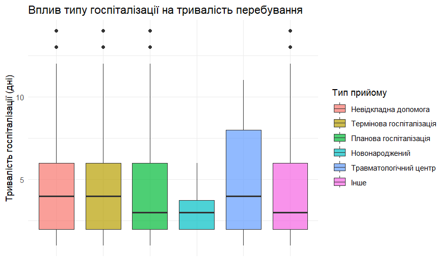

```r
data <- data %>%
  mutate(admission_type_id = as.factor(case_when(
    admission_type_id %in% c(5, 6, 8) ~ "Other",
    TRUE ~ as.character(admission_type_id)
  ))) %>%
  mutate(admission_type_id = recode(admission_type_id,
    "1" = "Невідкладна допомога",
    "2" = "Термінова госпіталізація",
    "3" = "Планова госпіталізація",
    "4" = "Новонароджений",
    "7" = "Травматологічний центр",
    "Other" = "Інше"
  ))

ggplot(data, aes(x = admission_type_id, y = time_in_hospital, fill = admission_type_id)) +
  geom_boxplot(alpha = 0.7) +
  labs(title = "Вплив типу госпіталізації на тривалість перебування",
       x = "",
       y = "Тривалість госпіталізації (дні)",
       fill = "Тип прийому") +
  theme_minimal() +
  theme(
    axis.text.x = element_blank(),  # Прибирає підписи категорій
    axis.ticks.x = element_blank()
  )
```

Загальний висновок: Тип госпіталізації впливає на тривалість перебування в лікарні.

Планові та термінові госпіталізації мають помірну тривалість.

Новонароджені перебувають у лікарні найменше часу.

# • Чи впливає кількість встановлених діагнозів

# на ймовірність летального наслідку?

# Нас цікавлять значення зі змінної discharge_disposition_id:

# 11, Термін дії минув

# 19, «Термін придатності закінчився вдома. Тільки Medicaid, хоспіс».

# 20, «Термін придатності минув у медичному закладі. Лише Medicaid, хоспіс».

# 21, «Термін дії закінчився, місце невідоме. Тільки Medicaid, хоспіс».

# Щільність 2d

# Здебільшого летальними наслідкам характерно не більше девяти діагнозів.

# Проте з графіку видно ,що у більшості людей не більше девяти діагнозів,

# а найчастіше саме девять діагнозів.

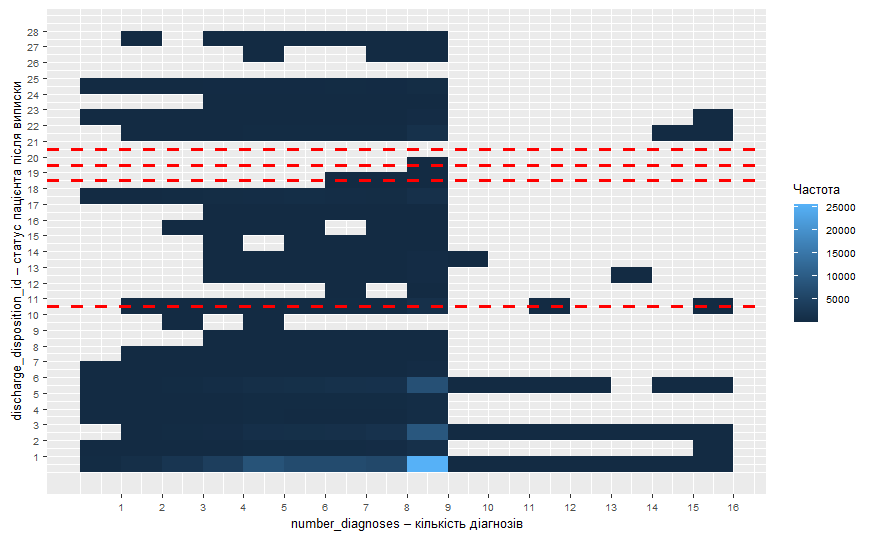

```r
ggplot(data, aes(x = number_diagnoses, y = discharge_disposition_id)) +

  geom_bin2d(binwidth = c(1, 1), origin = c(-1, -1)) +

  scale_x_continuous(
    breaks = 1:17,
    labels = 1:17
  ) +

  scale_y_continuous(
    breaks = 1:28,
    labels = 1:28
  ) +

  geom_hline(
    yintercept = c(10.5, 18.5, 19.5, 20.5),
    linetype = "dashed",
    color = "red",
    size = 1
  ) +

  labs(
    x = "number_diagnoses – кількість діагнозів",
    y = "discharge_disposition_id – статус пацієнта після виписки"
  ) +

  scale_fill_gradient(name = "Частота") +

  theme(
    axis.title = element_text(size = 8),
    axis.text = element_text(size = 6),
    legend.text = element_text(size = 6),
    legend.title = element_text(size = 8),
    legend.key.size = unit(0.5, "cm")  # зменшено
  )
```

```r
NA
NA
```